# SEMESTER FINAL PROJECT

Author

EMAN A. AWAN

## Introduction

I got my data set from Varieties of Democracy, but downloaded it of off canvas. Egalitarian and participatory democracies both uphold fundamental principles including justice, inclusivity, and equality. Ensuring that citizens have a direct say in the policies that impact their lives is one way that participatory democracy can be used to accomplish egalitarian objectives. Conversely, participatory processes can help guarantee inclusive and representational decision-making in an egalitarian democracy. I hope to learn the value between citizen involvement and a dedication to decreasing social and economic inequality by comprehending the relationship between these notions.

My data source obtained the data I used by collecting the data from observations and surveys.I got my data Varieties of Democracy.

My two variables are Participatory Democracy Index (v2x_partipdem), Egalitarian Democracy Index (v2x_egaldem).

## Summary Statistices of the variables

```r
library(readr)
proj_data <- read_csv("~/Documents/Project data/proj_data.csv")
```

```
──────────────────────────────────────────────────────── Delimiter: "," chr
(2): country_name, country_text_id dbl (9): ...1, country_id, v2xcs_ccsi,
v2x_gencs, v2x_delibdem, v2x_egaldem,...
```

```r
head(proj_data)
```

```
# A tibble: 6 × 11
   ...1 country_name country_text_id country_id v2xcs_ccsi v2x_gencs
  <dbl> <chr>        <chr>                <dbl>      <dbl>     <dbl>
1   230 Mexico       MEX                      3      0.86      0.818
2   353 Suriname     SUR                      4      0.93      0.823
3   587 Sweden       SWE                      5      0.976     0.858
4   812 Switzerland  CHE                      6      0.956     0.877
5   933 Ghana        GHA                      7      0.96      0.775
6  1056 South Africa ZAF                      8      0.936     0.839
# ℹ 5 more variables: v2x_delibdem <dbl>, v2x_egaldem <dbl>, v2x_libdem <dbl>,
#   v2x_partipdem <dbl>, v2x_polyarchy <dbl>
```

```r
as.numeric(length(proj_data$v2x_egaldem))
```

```
[1] 179
```

```r
median(proj_data$v2x_egaldem)
```

```
[1] 0.347
```

```r
mean(proj_data$v2x_egaldem)
```

```
[1] 0.3929274
```

```r
var(proj_data$v2x_egaldem)
```

```
[1] 0.05626485
```

```r
sd(proj_data$v2x_egaldem)
```

```
[1] 0.2372021
```

```r
summary(proj_data$v2x_egaldem)
```

```
   Min. 1st Qu.  Median    Mean 3rd Qu.    Max.
 0.0280  0.1930  0.3470  0.3929  0.5940  0.8820
```

```r
as.numeric(length(proj_data$v2x_partipdem))
```

```
[1] 179
```

```r
median(proj_data$v2x_partipdem)
```

```
[1] 0.33
```

```r
mean(proj_data$v2x_partipdem)
```

```
[1] 0.3375642
```

```r
var(proj_data$v2x_partipdem)
```

```
[1] 0.03930313
```

```r
sd(proj_data$v2x_partipdem)
```

```
[1] 0.1982502
```

```r
summary(proj_data$v2x_partipdem)
```

```
   Min. 1st Qu.  Median    Mean 3rd Qu.    Max.
 0.0090  0.1680  0.3300  0.3376  0.4815  0.8120
```

## Histograms of the variables

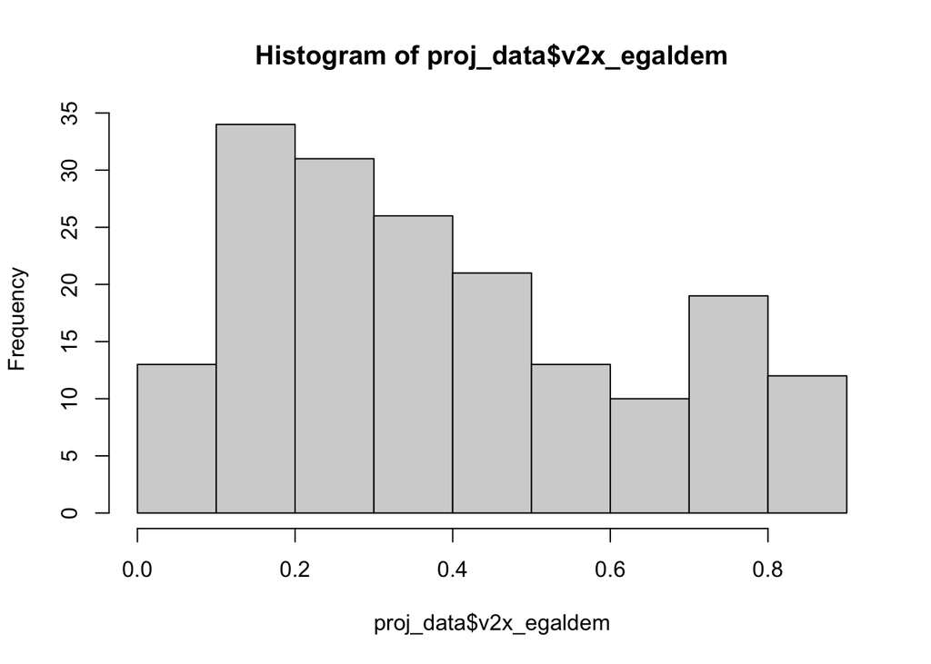

```r
hist(proj_data$v2x_egaldem)
```

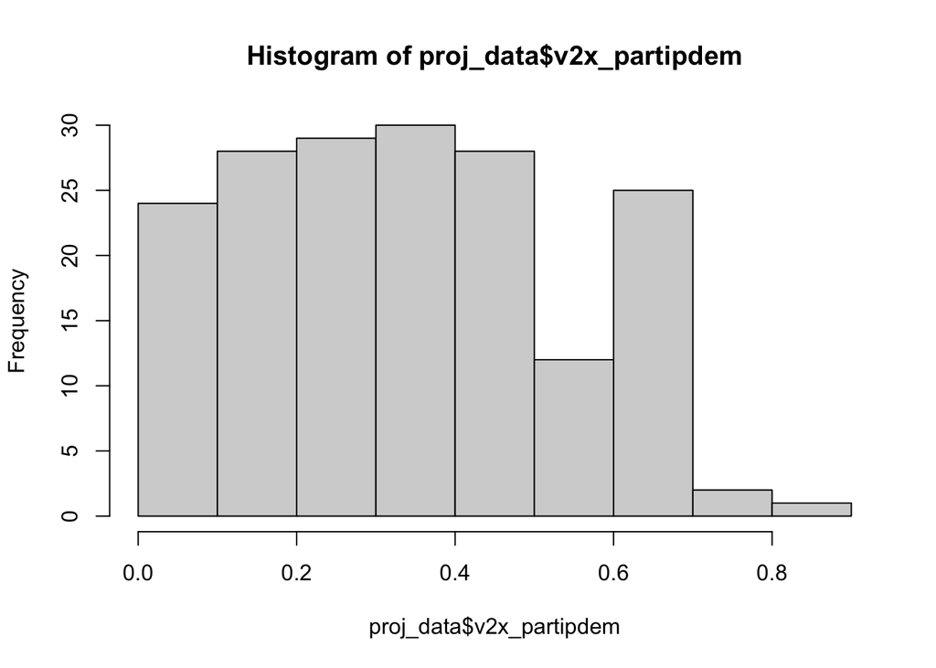

```r
hist(proj_data$v2x_partipdem)
```